# Making a heatmap with annotation bars using refine.bio data

July 2019

*This notebook is derived from the Alex’s Lemonade Stand Foundation [Childhood Cancer Data Lab](https://www.ccdatalab.org/) example workflows.*

## Introduction

In this notebook, we will use [refine.bio](https://www.refine.bio/)-processed data from [`GSE39842`](https://www.refine.bio/experiments/GSE39842/hypoxia-induces-myocardial-regeneration-in-zebrafish) ([Link to GEO Series](https://www.ncbi.nlm.nih.gov/geo/query/acc.cgi?acc=GSE39842)).

Here is the description from the authors:

> Conditional expression of dominant-negative HIF1a in zebrafish cardiomyocytes severely inhibits heart regeneration. To understand more about the mechanism, we performed microarray analysis of wildtype regenerating zebrafish and dnHIF1a regenerating zebrafish to determine which genes are regulated by hypoxia/HIF1a.

We’re going to make a heatmap of high variance genes in this experiment. Because we’re interested in the *genotype* (i.e., dnHIF1a-expressing) and the *treatment* (i.e., amputation/injury), we will add annotation bars to the heatmap torepresent this information. The [`ComplexHeatmap` package](https://bioconductor.org/packages/release/bioc/html/ComplexHeatmap.html) allows us to do this. The *ComplexHeatmap Complete Reference* can be found [here](https://jokergoo.github.io/ComplexHeatmap-reference/book/).

## Setup

Install required packages if they are not already installed.

```r
# if ComplexHeatmap is NOT in the list of installed packages, install it
if (!("ComplexHeatmap" %in% installed.packages())) {
  BiocManager::install("ComplexHeatmap", update = FALSE)
}

if (!("dplyr" %in% installed.packages())) {
  install.packages("dplyr")
}
```

Load packages.

```r
library(ComplexHeatmap)
library(dplyr)
```

## Read in data

### Gene expression matrix

```r
expression_df <- read.delim(file.path("refinebio-data", "GSE39842",
                                      "GSE39842.tsv"),
                            stringsAsFactors = FALSE)
head(expression_df)
```

|  | Gene | GSM980276 | GSM980278 | GSM980280 | GSM980282 | GSM980273 | GSM980283 | GSM980274 | GSM980284 | GSM980279 | GSM980277 | GSM980281 | GSM980275 |
| --- | --- | --- | --- | --- | --- | --- | --- | --- | --- | --- | --- | --- | --- |
| 1 | ENSDARG00000000018 | 0.47305049 | 0.41004334 | 0.24501868 | 0.3587296 | 0.52134906 | 0.35747653 | 0.43310781 | 0.40073829 | 0.23915111 | 0.39784425 | 0.3010251 | 0.50892751 |
| 2 | ENSDARG00000000019 | 0.40690150 | 0.47706008 | 0.48595250 | 0.7801473 | 0.44885143 | 0.52668930 | 0.49408269 | 0.75742798 | 0.51920439 | 0.47764940 | 0.5781870 | 0.48802309 |
| 3 | ENSDARG00000000068 | 0.23969143 | 0.19468993 | 0.12828150 | 0.2284070 | 0.09959870 | 0.16269764 | 0.13966330 | 0.23318611 | 0.09981957 | 0.14266135 | 0.1950007 | 0.16804809 |
| 4 | ENSDARG00000000069 | 0.68386151 | 0.56505253 | 0.53310827 | 0.6083235 | 0.45674574 | 0.63115917 | 0.49746362 | 0.56874191 | 0.45431926 | 0.54481143 | 0.4953295 | 0.52703299 |
| 5 | ENSDARG00000000103 | 1.61616719 | 1.81682285 | 1.37914588 | 1.8250222 | 1.47409703 | 1.59957870 | 1.51168974 | 1.78572442 | 1.39083736 | 1.79702130 | 1.3500788 | 1.35625541 |
| 6 | ENSDARG00000000151 | -0.09455442 | -0.06848165 | -0.09826915 | 0.1184429 | -0.09023467 | -0.02379229 | -0.03824752 | 0.04639932 | -0.02096598 | -0.04728156 | -0.0259283 | -0.07714578 |

```r
expression_matrix <- as.matrix(expression_df[, -1])
rownames(expression_matrix) <- expression_df$Gene
```

Use apply to calculate the variance of the values in each row. We’ll limit our heatmap to the genese with the highest variance (top 10%).

```r
row_variances <- apply(expression_matrix, 1, var)
summary(row_variances)
```

```
     Min.   1st Qu.    Median      Mean   3rd Qu.      Max.
0.0001083 0.0013837 0.0040326 0.0149440 0.0119220 1.0313982
```

```r
# top 10% of genes in terms of variances
high_variance_genes <- which(row_variances > quantile(row_variances, 0.9))
```

```r
# we use the indices of the high variance genes to select them from the
# expression matrix
high_variance_matrix <- expression_matrix[high_variance_genes, ]
```

### Metadata

```r
metadata_df <- read.delim(file.path("refinebio-data", "GSE39842",
                                    "metadata_GSE39842.tsv"),
                          stringsAsFactors = FALSE)
colnames(metadata_df)
```

```
 [1] "refinebio_accession_code"      "refinebio_age"                 "refinebio_cell_line"
 [4] "refinebio_compound"            "refinebio_disease"             "refinebio_disease_stage"
 [7] "refinebio_genetic_information" "refinebio_organism"            "refinebio_platform"
[10] "refinebio_race"                "refinebio_sex"                 "refinebio_source_archive_url"
[13] "refinebio_source_database"     "refinebio_specimen_part"       "refinebio_subject"
[16] "refinebio_time"                "refinebio_title"               "refinebio_treatment"
[19] "channel_count"                 "contact_address"               "contact_city"
[22] "contact_country"               "contact_department"            "contact_email"
[25] "contact_institute"             "contact_laboratory"            "contact_name"
[28] "contact_phone"                 "contact_zip.postal_code"       "data_processing"
[31] "data_row_count"                "description"                   "developmental.stage"
[34] "extract_protocol_ch1"          "genotype"                      "geo_accession"
[37] "hyb_protocol"                  "label_ch1"                     "label_protocol_ch1"
[40] "last_update_date"              "line"                          "molecule_ch1"
[43] "organism_ch1"                  "platform_id"                   "scan_protocol"
[46] "series_id"                     "source_name_ch1"               "status"
[49] "submission_date"               "supplementary_file"            "taxid_ch1"
[52] "time.post.treatment"           "tissue"                        "title"
[55] "treatment"                     "type"
```

```r
View(metadata_df)
```

```r
metadata_df <- metadata_df[, c("refinebio_accession_code",
                               "genotype",
                               "refinebio_treatment")]
```

Reorder the columns of the expression matrix containing only the genes with the highest variance

```r
# using sort here will insure that the sample identifiers (colnames) are in
# ascending order
high_variance_matrix <- high_variance_matrix[, sort(colnames(high_variance_matrix))]
```

Reorder the metadata

```r
# sort the data.frame such that the accession codes are in ascending order
# using the arrange function from the dplyr package
metadata_df <- arrange(metadata_df, refinebio_accession_code)
metadata_df
```

| refinebio_accession_code | genotype | refinebio_treatment |
| --- | --- | --- |
| GSM980273 | Tg(cmlc2a:Ert2-Cre-Ert2/cmlc2a:LnL:GFP)(cmlc2a:LrL:dnHIF1a) | none |
| GSM980274 | Tg(cmlc2a:Ert2-Cre-Ert2/cmlc2a:LnL:GFP)(cmlc2a:LrL:dnHIF1a) | none |
| GSM980275 | Tg(cmlc2a:Ert2-Cre-Ert2/cmlc2a:LnL:GFP)(cmlc2a:LrL:dnHIF1a) | none |
| GSM980276 | wildtype | none |
| GSM980277 | wildtype | none |
| GSM980278 | wildtype | none |
| GSM980279 | Tg(cmlc2a:Ert2-Cre-Ert2/cmlc2a:LnL:GFP)(cmlc2a:LrL:dnHIF1a) | amputation |
| GSM980280 | Tg(cmlc2a:Ert2-Cre-Ert2/cmlc2a:LnL:GFP)(cmlc2a:LrL:dnHIF1a) | amputation |
| GSM980281 | Tg(cmlc2a:Ert2-Cre-Ert2/cmlc2a:LnL:GFP)(cmlc2a:LrL:dnHIF1a) | amputation |
| GSM980282 | wildtype | amputation |

[output cut: 2 more lines]

Check that the order of the samples is the same in the metadata and the expression matrix.

```r
all.equal(metadata_df$refinebio_accession_code, colnames(high_variance_matrix))
```

```
[1] TRUE
```

## Make the heatmap

We’ll use only the high variance genes.

### Annotation bars

First, let’s get the annotation bars set up. `metadata_df` contains the information we need to annotate samples (columns) with. Specifically, it contains the genotype and amputation status information.

```r
column_annotation <- HeatmapAnnotation(
  df = metadata_df[, -1],
  # note that the values here match the values of what is in the column
  col = list(genotype = c("Tg(cmlc2a:Ert2-Cre-Ert2/cmlc2a:LnL:GFP)(cmlc2a:LrL:dnHIF1a)" = "#00BFFF",
                          "wildtype" = "#FFD700"),
             refinebio_treatment = c("none" = "#FF7F00",
                                     "amputation" = "#4EEE94"))
)
```

### Heatmap

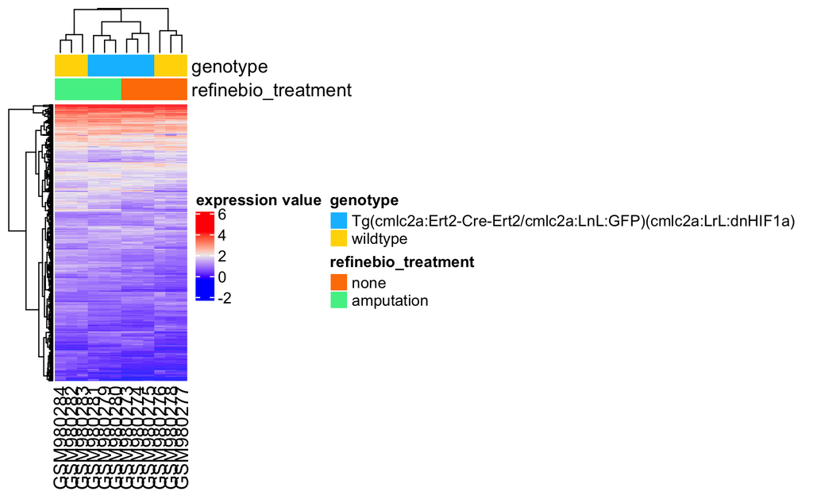

```r
Heatmap(high_variance_matrix,
        show_row_names = FALSE,
        name = "expression value",
        top_annotation = column_annotation)
```

By cleaning the metadata a bit, we can make this easier to read.

```r
# mutate will change the genotype column in metadata_df to be easier to read
# recode allows us to change the value of this column
# these are both from the dplyr library
cleaned_metadata_df <- mutate(
  metadata_df,
  genotype = recode(
    genotype,
    "Tg(cmlc2a:Ert2-Cre-Ert2/cmlc2a:LnL:GFP)(cmlc2a:LrL:dnHIF1a)" = "dnHIF1a-expressing"
  ))
```

We can also change the column names of `cleaned_metadata_df` to control the annotation bar labels.

```r
# we can rename the 'refinebio_treatment' column to simply 'treatment'
cleaned_metadata_df <- rename(cleaned_metadata_df,
                              treatment = refinebio_treatment)
```

Remake the column annotation object with the cleaned metadata.

```r
column_annotation <- HeatmapAnnotation(
  df = cleaned_metadata_df[, -1],
  # note that the values here match the values of what is in the column
  col = list(genotype = c("dnHIF1a-expressing" = "#00BFFF",
                         "wildtype" = "#FFD700"),
             treatment = c("none" = "#FF7F00",
                           "amputation" = "#4EEE94"))
)
```

Now we’re ready to remake the heatmap!

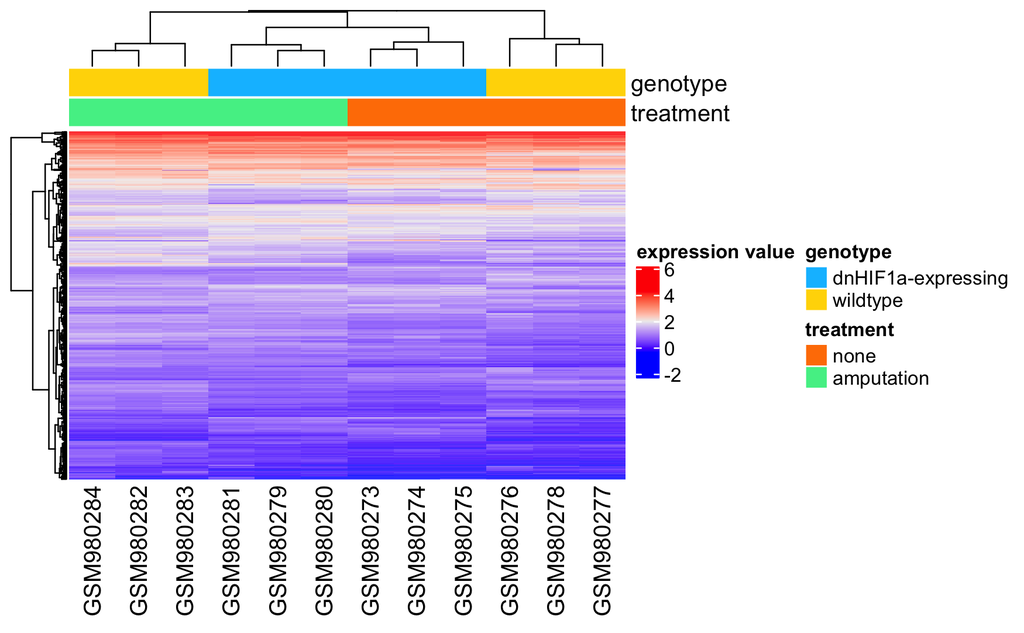

```r
Heatmap(high_variance_matrix,
        show_row_names = FALSE,
        name = "expression value",
        top_annotation = column_annotation)
```